# STAT 240: The Bob Ross Case Study: Solutions

## Visualization

> Using the results of the previous exercise, imitate the following visualization:

[figure not shown]

A horizontal bar chart from FiveThirtyEight’s article at https://fivethirtyeight.com/features/a-statistical-analysis-of-the-work-of-bob-ross/.

- Our visualization will be slightly different than FiveThirtyEight’s; theirs includes frames, and makes some modifications to the column names for clarity.

Important features of the graph to recreate include:

- Title and subtitle, axis labels
- The ordering of the bars
- The feature names are not in all caps
- The percentages are included as text to the right of each bar
- The purposeful lack of axes and grid markings
- Only features which appear at least 2% of the time are shown
- Remember that creating a ggplot is an *iterative* process, and you shouldn’t try to do all of these things at once! Get the base form, then add each customization one by one, checking your work as you go along.

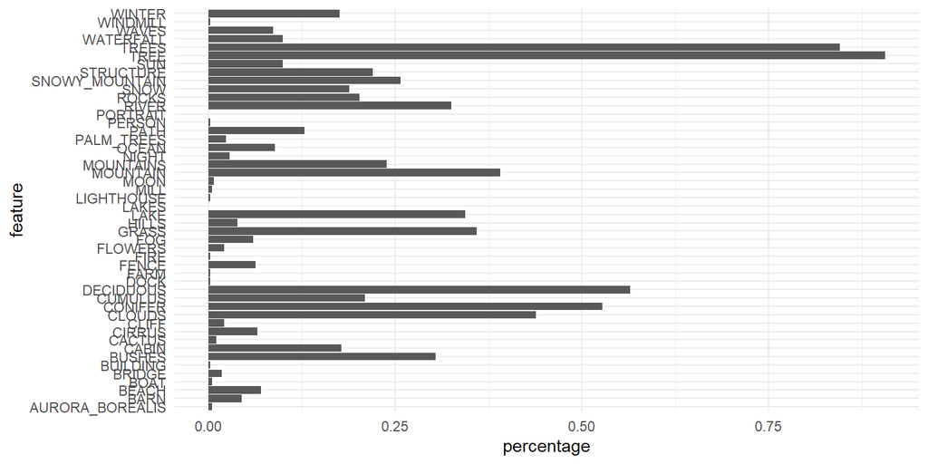

```r
# The very base form of the graph: features on the left, with horizontal bars indicating percentages.
ggplot(painting_element_counts, aes(y = feature, x = percentage)) +
  geom_col()
```

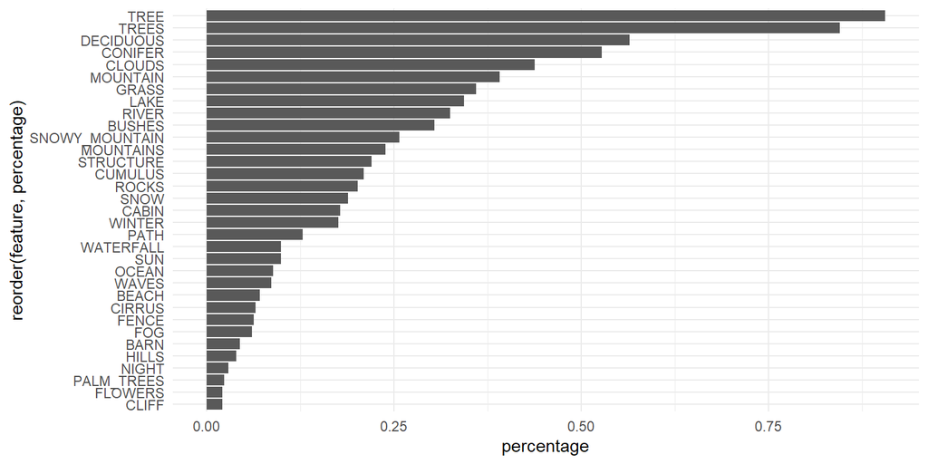

```r
# Another big step: Taking out all the very rare features, reordering the bars with reorder() within aes()
painting_element_counts %>%
  filter(percentage > 0.02) %>%
ggplot(aes(y = reorder(feature, percentage), x = percentage)) +
  geom_col()
```

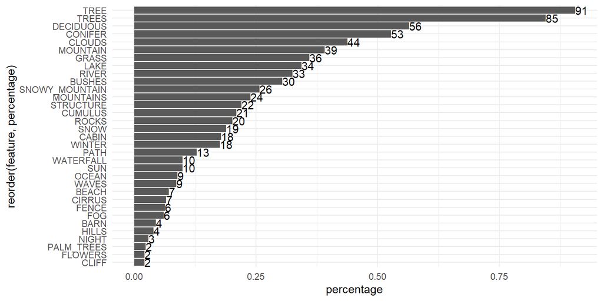

```r
# Final "geom" element to add: the percentage labels through geom_text()
painting_element_counts %>%
  filter(percentage > 0.02) %>%
ggplot(aes(y = reorder(feature, percentage), x = percentage)) +
  geom_col() +
  # label should be set within aes() because it is a variable aesthetic
  geom_text(aes(label = round(percentage*100)), hjust = "left")
```

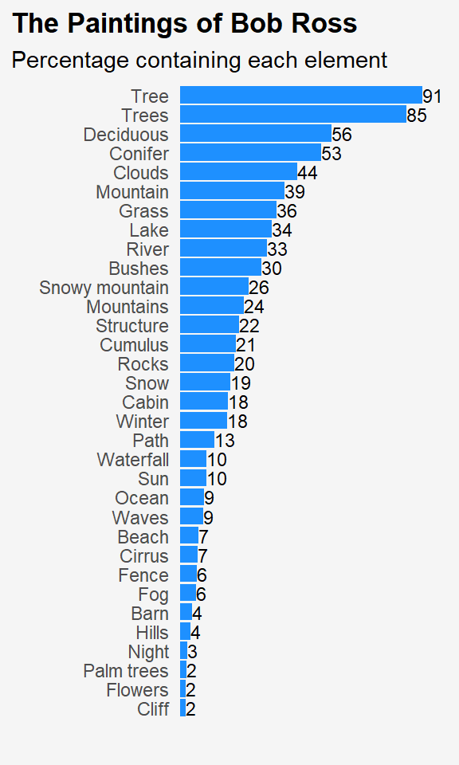

```r
# From here it's all purely visual modifications! Note the fig.height and fig.width adjustment above.

painting_element_counts %>%
  filter(percentage > 0.02) %>%
  # Change the feature names from "THIS_FORMAT" to "This format"
  mutate(feature = str_to_sentence(feature),
         feature = str_replace(feature, "_", " ")) %>%

ggplot(aes(y = reorder(feature, percentage), x = percentage)) +
  # Fill the bars dodgerblue
  geom_col(fill = "dodgerblue") +
  geom_text(aes(label = round(percentage*100)), hjust = "left", size = 3) +
  # Reduce that space between the feature labels and the bars
  scale_x_continuous(
    expand = expansion(mult = c(0, 0.1))
  ) +

  # Get rid of the grid and x axis labels, make the background all light gray
  theme(
    panel.grid = element_blank(),
    axis.text.x = element_blank(),
    plot.background = element_rect(fill = "gray96", color = "gray96"),
    plot.title.position = "plot",
    plot.title = element_text(face = "bold")
  ) +

  # Add plot labels and take away axis titles
  labs(
    title = "The Paintings of Bob Ross",
    subtitle = "Percentage containing each element",
    x = "",
    y = ""
  )
```

```r
# new command: ggsave! Saves the last ggplot you created.
ggsave("MyBobRossPlot.png")
```

# Colors by Episode

- Our second dataset, `bob_ross_paintings.csv`, is courtesy of TwoInchBrush.com courtesy of GitHub user `jwilber`, and can be found [here](https://github.com/jwilber/Bob_Ross_Paintings).
  - TwoInchBrush.com is a website dedicated to *The Joy of Painting*, including a database of information on each one, and GitHub user `jwilber` scraped and collected the data into one file.

> Each of the 403 rows of `bob_ross_paintings.csv` represents one painting. Just like in the first dataset, this is equivalent to representing one episode, since there was exactly one painting each episode.

```r
painting_colors = read_csv("../../data/bob_ross_paintings.csv")

nrow(painting_colors)
```

```
## [1] 403
```

```r
painting_colors %>%
  head()
```

```
## # A tibble: 6 × 28
##    ...1 painting_index img_src          painting_title season episode num_colors
##   <dbl>          <dbl> <chr>            <chr>           <dbl>   <dbl>      <dbl>
## 1     1            282 https://www.two… A Walk in the…      1       1          8
## 2     2            283 https://www.two… Mt. McKinley        1       2          8
## 3     3            284 https://www.two… Ebony Sunset        1       3          9
## 4     4            285 https://www.two… Winter Mist         1       4          3
## 5     5            286 https://www.two… Quiet Stream        1       5          8
## 6     6            287 https://www.two… Winter Moon         1       6          4
## # ℹ 21 more variables: youtube_src <chr>, colors <chr>, color_hex <chr>,
## #   Black_Gesso <dbl>, Bright_Red <dbl>, Burnt_Umber <dbl>,
## #   Cadmium_Yellow <dbl>, Dark_Sienna <dbl>, Indian_Red <dbl>,
## #   Indian_Yellow <dbl>, Liquid_Black <dbl>, Liquid_Clear <dbl>,
## #   Midnight_Black <dbl>, Phthalo_Blue <dbl>, Phthalo_Green <dbl>,
## #   Prussian_Blue <dbl>, Sap_Green <dbl>, Titanium_White <dbl>,
## #   Van_Dyke_Brown <dbl>, Yellow_Ochre <dbl>, Alizarin_Crimson <dbl>
```

- When we first read in the data, there are 28 columns giving information about the episode and the painting, with particular emphasis on the colors, but only a few we’ll be interested in:
  - `painting_title`, the title of the painting
  - `season` and `episode`, which together uniquely identify each row,
  - `num_colors`, the number of how many different colors the host uses,
  - and 18 columns at the end with names ranging from `Black_Gesso` to `Alizarin_Crimson` which take on values 0 if that color does not appear in that painting, and 1 if it does.

## Visualization

> Create a plot visualizing the distribution of the number of colors used, `num_colors`.
- There is an underlying consideration to be made here; should we treat `num_colors` as a discrete variable or a continuous one?
  - It is most easily considered a discrete variable. It can only take on integers, and it happens to only take on integers in a relatively small range.
  - However, we could treat it as a continuous one. To do so would be to overlook the fundamental nature of its values, but it would allow us to conduct means and regression inference on it.
- This is a very common situation in real data science where the line is blurred between a discrete and continuous variable, and we often have to switch our thinking from one type to the other.

> When we **visualize** `num_colors`, we will stay true to its discrete nature, but we will treat it as a continuous variable for inference purposes.

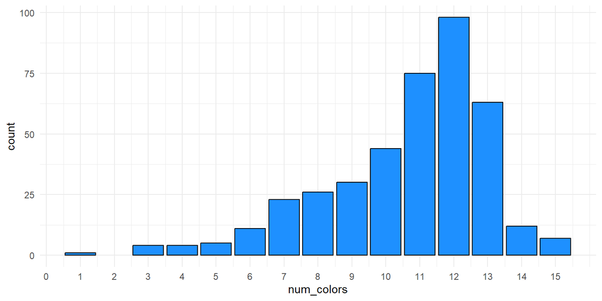

```r
# Write code here to visualize the distribution of num_colors.

# Here's one option with geom_bar, which I think is the best; the space between the bars emphasizes that num_colors cannot take on decimal values
ggplot(painting_colors) +
  geom_bar(aes(x = num_colors),
                 color = "black", fill = "dodgerblue")  +

  # Improved axis labeling
  scale_x_continuous(
    breaks = 0:15
  )
```

```r
# There are many other visual improvements we could make to this plot - see the previous visualization exercise for inspiration.
```

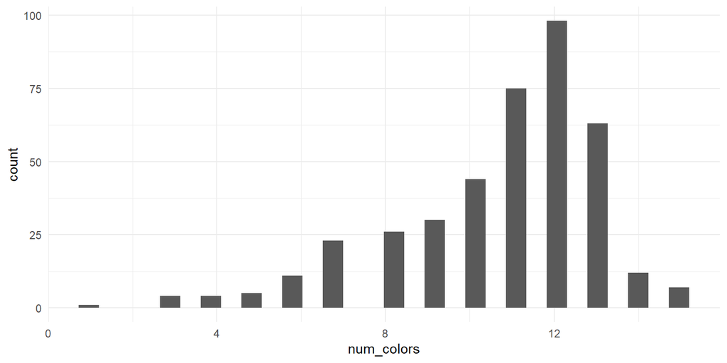

```r
# You could also do this with geom_histogram.

# By default, notice the bins are not centered around the whole numbers
ggplot(painting_colors) +
  geom_histogram(aes(x = num_colors))
```

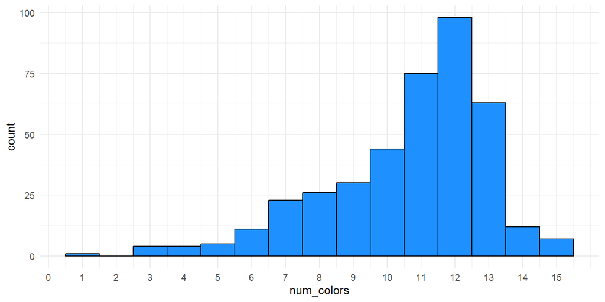

```r
# center = 12 could be any whole number, it just means to start with a bin that's 1.0 wide, centered at 12.0, and then build out from there.

# However, I don't like this as much because the lack of gaps between the bars implies visually that num_colors can take on any value in this range.

ggplot(painting_colors) +
  geom_histogram(aes(x = num_colors),
                 binwidth = 1, center = 12,
                 color = "black", fill = "dodgerblue")  +

  # Improved axis labeling
  scale_x_continuous(
    breaks = 0:15
  )
```

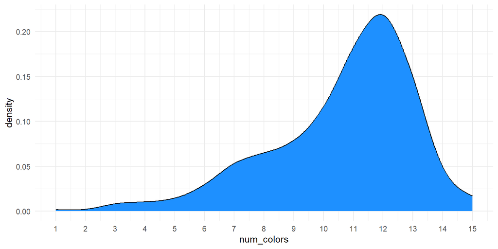

```r
# geom_density does an even worse job of emphasizing that num_colors only takes on integers.

ggplot(painting_colors) +
  geom_density(aes(x = num_colors),
                 color = "black", fill = "dodgerblue")  +

  # Improved axis labeling
  scale_x_continuous(
    breaks = 0:15
  )
```

##### Sidenote: What’s that Outlier?

- It looks like there’s one painting that just has one color in it. Very often exploratory data analysis will lead to you discovering an outlier like this in a key variable, which leads to questions like:

*“Is that real or a data entry error?”*

*“If that was real, what was going on with that observation?”*

- Very often, you will have to dedicate some outside research to these outliers!

> Do some in-class investigation into the outlier - look at the painting and the video, links in the dataset!

```r
painting_colors %>%
  filter(num_colors == 1) %>%
  relocate(img_src, youtube_src, season, episode, painting_title)
```

```
## # A tibble: 1 × 28
##   img_src         youtube_src season episode painting_title  ...1 painting_index
##   <chr>           <chr>        <dbl>   <dbl> <chr>          <dbl>          <dbl>
## 1 https://www.tw… https://ww…     16       6 Contemplative…   201             89
## # ℹ 21 more variables: num_colors <dbl>, colors <chr>, color_hex <chr>,
## #   Black_Gesso <dbl>, Bright_Red <dbl>, Burnt_Umber <dbl>,
## #   Cadmium_Yellow <dbl>, Dark_Sienna <dbl>, Indian_Red <dbl>,
## #   Indian_Yellow <dbl>, Liquid_Black <dbl>, Liquid_Clear <dbl>,
## #   Midnight_Black <dbl>, Phthalo_Blue <dbl>, Phthalo_Green <dbl>,
## #   Prussian_Blue <dbl>, Sap_Green <dbl>, Titanium_White <dbl>,
## #   Van_Dyke_Brown <dbl>, Yellow_Ochre <dbl>, Alizarin_Crimson <dbl>
```

- This dataset, luckily for us, has links to the associated painting and [video](https://www.youtube.com/embed/gnp6WE7Ql-s). The painting is shown below.

[figure not shown]

The Joy of Painting, Season 16, Episode 6: “A Contemplative Lady”.

- That doesn’t look like something Bob would make! Let’s spend a minute watching the [video](https://www.youtube.com/embed/gnp6WE7Ql-s) to see what’s up.
- This is a real painting that appeared on the show, made by Bob’s instructor, John Thamm!
- This reminds us… some of these episodes are guest hosts, not Bob himself!
- We have that information back in the original `all_elements` FiveThirtyEight dataset, but not this one.
- That naturally leads us to…

# Joining the Two Datasets

- We are eventually interested in comparing the color features from the `painting_colors` dataframe to various features of the FiveThirtyEight `all_elements` dataframe.
- We need to `join` the two datasets together.
- However, the dataframes don’t share a variable or variables that we can join by… yet.

```r
all_elements %>%
  select(EPISODE, TITLE)
```

```
## # A tibble: 403 × 2
##    EPISODE TITLE
##    <chr>   <chr>
##  1 S01E01  "\"A WALK IN THE WOODS\""
##  2 S01E02  "\"MT. MCKINLEY\""
##  3 S01E03  "\"EBONY SUNSET\""
##  4 S01E04  "\"WINTER MIST\""
##  5 S01E05  "\"QUIET STREAM\""
##  6 S01E06  "\"WINTER MOON\""
##  7 S01E07  "\"AUTUMN MOUNTAINS\""
##  8 S01E08  "\"PEACEFUL VALLEY\""
##  9 S01E09  "\"SEASCAPE\""
## 10 S01E10  "\"MOUNTAIN LAKE\""
## # ℹ 393 more rows
```

```r
painting_colors %>%
  select(season, episode, painting_title)
```

```
## # A tibble: 403 × 3
##    season episode painting_title
##     <dbl>   <dbl> <chr>
##  1      1       1 A Walk in the Woods
##  2      1       2 Mt. McKinley
##  3      1       3 Ebony Sunset
##  4      1       4 Winter Mist
##  5      1       5 Quiet Stream
##  6      1       6 Winter Moon
##  7      1       7 Autumn Mountain
##  8      1       8 Peaceful Valley
##  9      1       9 Seascape
## 10      1      10 Mountain Lake
## # ℹ 393 more rows
```

> Write code to create a common variable or variables across the two dataframes, and then join them. Save this joined dataframe as `paintings_joined`.
- There are three potential ways to do this, including:
  - Combining `episode` and `season` from `painting_colors` into one variable which mimics `EPISODE` from `all_elements`
  - Separating `EPISODE` into two variables which mimic `episode` and `season`
  - Making `TITLE` and `painting_title` compatible. (This will eventually run into an issue, but it is worth considering as an instructive exercise.)

```r
# Write your code here!

# Way #1: episode and season -> EPISODE
# We need to turn 1 and 1 into "S01E01", with added 0's
# However, 10 and 10 becomes "S10E10", with no added 0's
# This combines boolean logic and string manipulation

# Printing at this stage a demonstration of how this is working
painting_colors %>%
  mutate(seasonChar = ifelse(season < 10, str_c("S0", season), str_c("S", season)),
         episodeChar = ifelse(episode < 10, str_c("E0", episode), str_c("E", episode)),
         EPISODE = str_c(seasonChar, episodeChar)) %>%
  select(season, episode, seasonChar, episodeChar, EPISODE)
```

```
## # A tibble: 403 × 5
##    season episode seasonChar episodeChar EPISODE
##     <dbl>   <dbl> <chr>      <chr>       <chr>
##  1      1       1 S01        E01         S01E01
##  2      1       2 S01        E02         S01E02
##  3      1       3 S01        E03         S01E03
##  4      1       4 S01        E04         S01E04
##  5      1       5 S01        E05         S01E05
##  6      1       6 S01        E06         S01E06
##  7      1       7 S01        E07         S01E07
##  8      1       8 S01        E08         S01E08
##  9      1       9 S01        E09         S01E09
## 10      1      10 S01        E10         S01E10
## # ℹ 393 more rows
```

```r
# With that EPISODE variable, we can join to all_elements
# This is the dataframe I'll actually bother to save in this solutions file, but all are equivalent
paintings_joined = painting_colors %>%
  mutate(seasonChar = ifelse(season < 10, str_c("S0", season), str_c("S", season)),
         episodeChar = ifelse(episode < 10, str_c("E0", episode), str_c("E", episode)),
         EPISODE = str_c(seasonChar, episodeChar)) %>%
  # The type of join we use doesn't matter since they have the same 403 rows
  full_join(all_elements, join_by(EPISODE))

# Just to display we have information from both dataframes
paintings_joined %>%
  select(EPISODE, TITLE, painting_title, num_colors, TREE)
```

```
## # A tibble: 403 × 5
##    EPISODE TITLE                     painting_title      num_colors  TREE
##    <chr>   <chr>                     <chr>                    <dbl> <dbl>
##  1 S01E01  "\"A WALK IN THE WOODS\"" A Walk in the Woods          8     1
##  2 S01E02  "\"MT. MCKINLEY\""        Mt. McKinley                 8     1
##  3 S01E03  "\"EBONY SUNSET\""        Ebony Sunset                 9     1
##  4 S01E04  "\"WINTER MIST\""         Winter Mist                  3     1
##  5 S01E05  "\"QUIET STREAM\""        Quiet Stream                 8     1
##  6 S01E06  "\"WINTER MOON\""         Winter Moon                  4     1
##  7 S01E07  "\"AUTUMN MOUNTAINS\""    Autumn Mountain              8     1
##  8 S01E08  "\"PEACEFUL VALLEY\""     Peaceful Valley              8     1
##  9 S01E09  "\"SEASCAPE\""            Seascape                     8     0
## 10 S01E10  "\"MOUNTAIN LAKE\""       Mountain Lake                8     1
## # ℹ 393 more rows
```

```r
# Way 2: Split EPISODE into episode and season
all_elements %>%
  mutate(season = as.numeric(str_sub(EPISODE, 2, 3)),
         episode = as.numeric(str_sub(EPISODE, 5, 6))) %>%
  # Just to display what season and episode are
  relocate(season, episode)
```

```
## # A tibble: 403 × 71
##    season episode EPISODE TITLE    APPLE_FRAME AURORA_BOREALIS  BARN BEACH  BOAT
##     <dbl>   <dbl> <chr>   <chr>          <dbl>           <dbl> <dbl> <dbl> <dbl>
##  1      1       1 S01E01  "\"A WA…           0               0     0     0     0
##  2      1       2 S01E02  "\"MT. …           0               0     0     0     0
##  3      1       3 S01E03  "\"EBON…           0               0     0     0     0
##  4      1       4 S01E04  "\"WINT…           0               0     0     0     0
##  5      1       5 S01E05  "\"QUIE…           0               0     0     0     0
##  6      1       6 S01E06  "\"WINT…           0               0     0     0     0
##  7      1       7 S01E07  "\"AUTU…           0               0     0     0     0
##  8      1       8 S01E08  "\"PEAC…           0               0     0     0     0
##  9      1       9 S01E09  "\"SEAS…           0               0     0     1     0
## 10      1      10 S01E10  "\"MOUN…           0               0     0     0     0
## # ℹ 393 more rows
## # ℹ 62 more variables: BRIDGE <dbl>, BUILDING <dbl>, BUSHES <dbl>, CABIN <dbl>,
## #   CACTUS <dbl>, CIRCLE_FRAME <dbl>, CIRRUS <dbl>, CLIFF <dbl>, CLOUDS <dbl>,
## #   CONIFER <dbl>, CUMULUS <dbl>, DECIDUOUS <dbl>, DIANE_ANDRE <dbl>,
## #   DOCK <dbl>, DOUBLE_OVAL_FRAME <dbl>, FARM <dbl>, FENCE <dbl>, FIRE <dbl>,
## #   FLORIDA_FRAME <dbl>, FLOWERS <dbl>, FOG <dbl>, FRAMED <dbl>, GRASS <dbl>,
## #   GUEST <dbl>, HALF_CIRCLE_FRAME <dbl>, HALF_OVAL_FRAME <dbl>, HILLS <dbl>, …
```

```r
# Proving the actual join works
all_elements %>%
    mutate(season = as.numeric(str_sub(EPISODE, 2, 3)),
          episode = as.numeric(str_sub(EPISODE, 5, 6))) %>%
  full_join(painting_colors) %>%
  select(EPISODE, TITLE, painting_title, num_colors, TREE)
```

```
## # A tibble: 403 × 5
##    EPISODE TITLE                     painting_title      num_colors  TREE
##    <chr>   <chr>                     <chr>                    <dbl> <dbl>
##  1 S01E01  "\"A WALK IN THE WOODS\"" A Walk in the Woods          8     1
##  2 S01E02  "\"MT. MCKINLEY\""        Mt. McKinley                 8     1
##  3 S01E03  "\"EBONY SUNSET\""        Ebony Sunset                 9     1
##  4 S01E04  "\"WINTER MIST\""         Winter Mist                  3     1
##  5 S01E05  "\"QUIET STREAM\""        Quiet Stream                 8     1
##  6 S01E06  "\"WINTER MOON\""         Winter Moon                  4     1
##  7 S01E07  "\"AUTUMN MOUNTAINS\""    Autumn Mountain              8     1
##  8 S01E08  "\"PEACEFUL VALLEY\""     Peaceful Valley              8     1
##  9 S01E09  "\"SEASCAPE\""            Seascape                     8     0
## 10 S01E10  "\"MOUNTAIN LAKE\""       Mountain Lake                8     1
## # ℹ 393 more rows
```

```r
# Way #3: Trying to coerce TITLE and painting_title to be the same.

# Right now, TITLE has quotes on the edges, and is in all caps.
# painting_title has "proper" capitalization. However, there is no way to get the TITLE "A WALK IN THE WOODS" or "MT. MCKINLEY" to have the proper capitalization "A Walk in the Woods" or "Mt. McKinley" across the board, so we're going to have to cast everything to uppercase or everything to lowercase.

elements_temp = all_elements %>%
  mutate(TITLE = str_remove_all(TITLE, "\""))

colors_temp = painting_colors %>%
  mutate(painting_title = str_to_upper(painting_title))

# Uh-oh... look at row 7. One has "AUTUMN MOUNTAIN" and the other has "AUTUMN MOUNTAINS", with an "s". That's not good. Sure, we could go in and fix that one, but if there's one, there might be more.
elements_temp %>% select(TITLE) %>% head(n = 7)
```

```
## # A tibble: 7 × 1
##   TITLE
##   <chr>
## 1 A WALK IN THE WOODS
## 2 MT. MCKINLEY
## 3 EBONY SUNSET
## 4 WINTER MIST
## 5 QUIET STREAM
## 6 WINTER MOON
## 7 AUTUMN MOUNTAINS
```

```r
colors_temp %>% select(painting_title) %>% head(n = 7)
```

```
## # A tibble: 7 × 1
##   painting_title
##   <chr>
## 1 A WALK IN THE WOODS
## 2 MT. MCKINLEY
## 3 EBONY SUNSET
## 4 WINTER MIST
## 5 QUIET STREAM
## 6 WINTER MOON
## 7 AUTUMN MOUNTAIN
```

```r
# We should have 403 rows, but we get 437 from a handful of titles not matching up. That suggests this is the wrong way to go.
full_join(elements_temp, colors_temp, join_by(TITLE == painting_title))
```

```
## # A tibble: 437 × 96
##    EPISODE TITLE   APPLE_FRAME AURORA_BOREALIS  BARN BEACH  BOAT BRIDGE BUILDING
##    <chr>   <chr>         <dbl>           <dbl> <dbl> <dbl> <dbl>  <dbl>    <dbl>
##  1 S01E01  A WALK…           0               0     0     0     0      0        0
##  2 S01E02  MT. MC…           0               0     0     0     0      0        0
##  3 S01E03  EBONY …           0               0     0     0     0      0        0
##  4 S01E04  WINTER…           0               0     0     0     0      0        0
##  5 S01E05  QUIET …           0               0     0     0     0      0        0
##  6 S01E06  WINTER…           0               0     0     0     0      0        0
##  7 S01E07  AUTUMN…           0               0     0     0     0      0        0
##  8 S01E08  PEACEF…           0               0     0     0     0      0        0
##  9 S01E09  SEASCA…           0               0     0     1     0      0        0
## 10 S01E10  MOUNTA…           0               0     0     0     0      0        0
## # ℹ 427 more rows
## # ℹ 87 more variables: BUSHES <dbl>, CABIN <dbl>, CACTUS <dbl>,
## #   CIRCLE_FRAME <dbl>, CIRRUS <dbl>, CLIFF <dbl>, CLOUDS <dbl>, CONIFER <dbl>,
## #   CUMULUS <dbl>, DECIDUOUS <dbl>, DIANE_ANDRE <dbl>, DOCK <dbl>,
## #   DOUBLE_OVAL_FRAME <dbl>, FARM <dbl>, FENCE <dbl>, FIRE <dbl>,
## #   FLORIDA_FRAME <dbl>, FLOWERS <dbl>, FOG <dbl>, FRAMED <dbl>, GRASS <dbl>,
## #   GUEST <dbl>, HALF_CIRCLE_FRAME <dbl>, HALF_OVAL_FRAME <dbl>, HILLS <dbl>, …
```

```r
# Furthermore, remember those titles that showed up multiple times in all_elements?
# They're not getting joined correctly either. Do the MOUNTAIN WATERFALL paintings have 12 colors or 11?

full_join(elements_temp, colors_temp, join_by(TITLE == painting_title)) %>%
  filter(TITLE == "LAKESIDE CABIN" | TITLE == "MOUNTAIN WATERFALL") %>% select(EPISODE, TITLE, TREE, num_colors)
```

```
## # A tibble: 8 × 4
##   EPISODE TITLE               TREE num_colors
##   <chr>   <chr>              <dbl>      <dbl>
## 1 S02E12  MOUNTAIN WATERFALL     1         12
## 2 S02E12  MOUNTAIN WATERFALL     1         11
## 3 S05E01  MOUNTAIN WATERFALL     1         12
## 4 S05E01  MOUNTAIN WATERFALL     1         11
## 5 S08E02  LAKESIDE CABIN         1         12
## 6 S08E02  LAKESIDE CABIN         1         12
## 7 S10E13  LAKESIDE CABIN         1         12
## 8 S10E13  LAKESIDE CABIN         1         12
```

# Statistical Inference

- We will use `paintings_joined` to investigate some interesting inference questions.

```r
# Some light cleaning of paintings_joined; getting rid of some redundant columns (we don't need TITLE and painting_title, painting_title is better formatted so we keep that, for example) and moving identifying columns to the front

paintings_joined = paintings_joined %>%
  # neat little trick; you can rename things within select!
  # it's also reordering the columns, like relocate() would.
  select(ID = EPISODE, season, episode, painting_title, num_colors, AURORA_BOREALIS:WINTER, Black_Gesso:Alizarin_Crimson)

paintings_joined
```

```
## # A tibble: 403 × 88
##    ID     season episode painting_title   num_colors AURORA_BOREALIS  BARN BEACH
##    <chr>   <dbl>   <dbl> <chr>                 <dbl>           <dbl> <dbl> <dbl>
##  1 S01E01      1       1 A Walk in the W…          8               0     0     0
##  2 S01E02      1       2 Mt. McKinley              8               0     0     0
##  3 S01E03      1       3 Ebony Sunset              9               0     0     0
##  4 S01E04      1       4 Winter Mist               3               0     0     0
##  5 S01E05      1       5 Quiet Stream              8               0     0     0
##  6 S01E06      1       6 Winter Moon               4               0     0     0
##  7 S01E07      1       7 Autumn Mountain           8               0     0     0
##  8 S01E08      1       8 Peaceful Valley           8               0     0     0
##  9 S01E09      1       9 Seascape                  8               0     0     1
## 10 S01E10      1      10 Mountain Lake             8               0     0     0
## # ℹ 393 more rows
## # ℹ 80 more variables: BOAT <dbl>, BRIDGE <dbl>, BUILDING <dbl>, BUSHES <dbl>,
## #   CABIN <dbl>, CACTUS <dbl>, CIRCLE_FRAME <dbl>, CIRRUS <dbl>, CLIFF <dbl>,
## #   CLOUDS <dbl>, CONIFER <dbl>, CUMULUS <dbl>, DECIDUOUS <dbl>,
## #   DIANE_ANDRE <dbl>, DOCK <dbl>, DOUBLE_OVAL_FRAME <dbl>, FARM <dbl>,
## #   FENCE <dbl>, FIRE <dbl>, FLORIDA_FRAME <dbl>, FLOWERS <dbl>, FOG <dbl>,
## #   FRAMED <dbl>, GRASS <dbl>, GUEST <dbl>, HALF_CIRCLE_FRAME <dbl>, …
```

## Single Proportion

> Construct an Agresti-Coull confidence interval for the true percentage/chance that a man-made `STRUCTURE` appears in a given painting.

> Before you do so, consider the BINS assumptions.
- We consider the observed episodes to be a sample of a larger, hypothetical population, infinitely many episodes of the show had it continued forever.
- Recall that an $\alpha$% confidence interval for the true $p$ asserts the true model is:

$$X \sim Binom(n, p)$$

where $X$ is the observed number of successes, $n$ is the pre-determined, fixed number of trials, and $p$ is the parameter of interest, the true probability a structure appears.

We would have to check the **BINS** assumptions, where:

- **B**inary trials is satisfied; there either is a structure or there is not.
- **I**ndependence is hesitantly satisfied; we can assume the episodes are not related to each other, though we may have to ask an expert to confirm there were no “themed” seasons or similar.
- **N**, fixed sample size, is satisfied: there are exactly 403 episodes.
- **S**ame probability is also hesitantly satisfied for the same reason as independence.
- Then, the form of the confidence interval is:

$$\hat{p}_{AC} \pm \text{qnorm}(\alpha+(1-\alpha)/2) *
\sqrt{\frac{\hat{p}_{AC}(1-\hat{p}_{AC})}{n+4}}$$

where,

$$\hat{p}_{AC} = \frac{X + 2}{n +4}$$

```r
# Write your code here!
structure_summary = paintings_joined %>%
  summarize(structures = sum(STRUCTURE),
    n = n())

structure_summary
```

```
## # A tibble: 1 × 2
##   structures     n
##        <dbl> <int>
## 1         85   403
```

```r
# Three inputs; successes, sample size, confidence level
x = structure_summary$structures
n = structure_summary$n
C = 0.95

# Calculate AC confidence interval
x_adjusted = x+2 # Added two successes
n_adjusted = n+4 # Added four data points total
phat = x_adjusted/n_adjusted
se = sqrt(phat * (1 - phat)/n_adjusted)  # Changes carry through to p_hat and n_adjusted
moe = qnorm(C + (1 - C)/2) * se

left = phat - moe
right = phat + moe

c(left, right)
```

```
## [1] 0.1739310 0.2535875
```

> We are 95% confident the true long-run probability that a man-made structure is painted in a TJOP episode is between 17.4% and 25.4%.

> Conduct a two-sided hypothesis test to assess the evidence that the true percentage of a `STRUCTURE` appearing is 20%.

*Note: From the confidence interval above, we should not be rejecting the null hypothesis here; the data are consistent with 20% being the true probability, we should get a p-value > 0.05.*

*Note II: This example is like the psychic example from week 9.*

- The model and assumptions were reviewed in the previous section; they are stated and met in the solutions file, hence we move right onto the hypotheses.

**Step 2: State hypotheses.**

$$H_0: p = 0.2$$

$$H_A: p \neq 0.2$$

**Step 3: Identify your test statistic and its sampling distribution.**

*Recall that single-proportion inference uses N(0,1) for confidence intervals and Binom(n, p) for hypothesis testing; this is the only type of inference where they’re different.*

- Our test statistic, the function of the sample whose distribution is known under the null hypothesis, is just $X$.
- When $H_0: p = 0.2$ is true, the null distribution of $X$ is:

$$X \sim Binom(403, 0.2)$$

**Step 4: Identify relevant outcomes from the data and the alternative hypothesis.**

- We observe $X = 85$ successes.
- Because $H_a: p \neq 0.2$ is two-sided, we identify the outcomes which are LESS likely than $X = 85$.

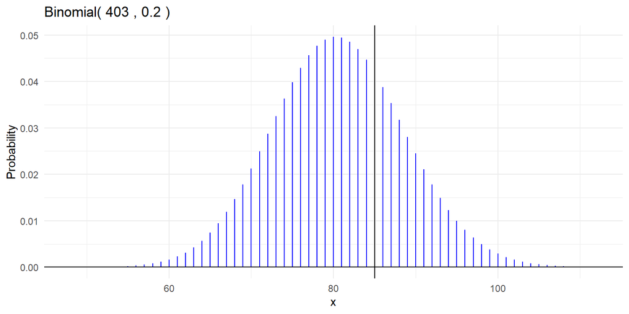

```r
gbinom(403, 0.2, scale = TRUE) +
  geom_vline(xintercept = 85)
```

- This sampling distribution may look symmetric.. but it is not!
- We are looking for the outcomes whose probability are less than or equal to:

```r
dbinom(85, 403, 0.2)
```

```
## [1] 0.04196199
```

- Naturally, this includes 85 and greater, but the left tail is a little harder to find:
- Zooming in on the center of the graph:

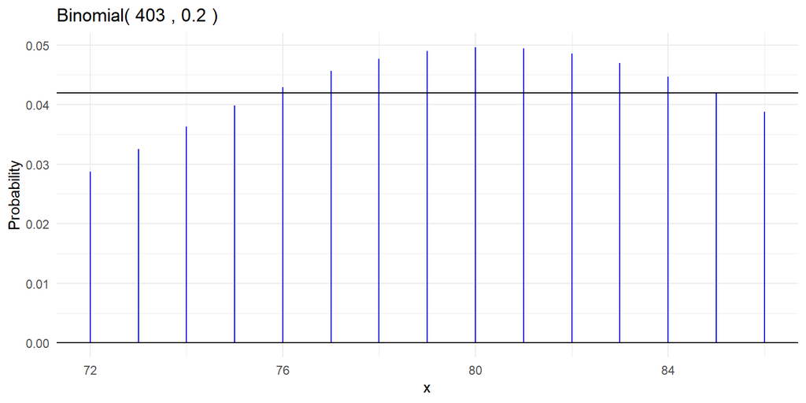

```r
gbinom(403, 0.2, a = 72, b = 86) +
  geom_hline(yintercept = dbinom(85, 403, 0.2))
```

- 75 is the last outcome on the left with lower probability than 85.
- Thus, our set of interest is **85 and greater**, as well as **75 and lower**.

**Step 5: Calculate p-value.**

- The area of **85 and greater** and **75 and lower** on $Binom(403, 0.2)$ is:

```r
pbinom(75, 403, 0.2) + pbinom(85 - 1, 403, 0.2, lower.tail = FALSE)
```

```
## [1] 0.5753965
```

**Step 6: Interpret in context.**

> We fail to find evidence against the true probability of a man-made structure appearing in a TJOP painting being 20%. (p-value = 0.58, two-sided single proportion test)

or,

> The data are consistent with the true probability of a man-made structure appearing in a TJOP painting being 20%. (p-value = 0.58, two-sided single proportion test)

## Difference in Proportions

> Construct a confidence interval for the difference in true proportions of a manmade structure appearing in episodes hosted by Bob vs. episodes hosted by guests.

**From this point out, the solutions file will become more limited in its full explanation of confidence intervals and hypothesis testing. I encourage you to refer to the relevant lecture notes from weeks 9, 10, and 11 for more detailed explanations, or to reach out if you have questions!**

```r
paintings_joined %>%
  group_by(GUEST) %>%
  summarize(X = sum(STRUCTURE),
            n = n())
```

```
## # A tibble: 2 × 3
##   GUEST     X     n
##   <dbl> <dbl> <int>
## 1     0    84   381
## 2     1     1    22
```

```r
x1 = 84
n1 = 381
x2 = 1
n2 = 22

# Confidence level
alpha = 0.95

# We will use "tilde" to refer to the AC-adjusted statistics
# This code computes the AC Confidence Interval for the true difference in two proportions
ntilde1 = n1 + 2
ntilde2 = n2 + 2
ptilde1 = (x1+1)/ntilde1
ptilde2 = (x2+1)/ntilde2

pe = ptilde1 - ptilde2

se1 = sqrt( ptilde1*(1-ptilde1)/ntilde1 )
se2 = sqrt( ptilde2*(1-ptilde2)/ntilde2 )
se = sqrt(se1^2 + se2^2 )
moe = qnorm(alpha + (1 - alpha)/2) * se

left = pe - moe
right = pe + moe

c(left, right)
```

```
## [1] 0.02045136 0.25674621
```

- Note that because $\hat{p}_2 = \frac{1}{22}$ is so extreme here, the Agresti-Coull adjustment really matters.
- If we had used the Wald adjustment instead, we would have gotten:

```r
# With Wald instead, not the Agresti-Coull as recommended; see above for that
p1 = x1/n1
p2 = x2/n2

pe = p1 - p2

se1 = sqrt( p1*(1-p1)/n1 )
se2 = sqrt( p2*(1-p2)/n2 )
se = sqrt(se1^2 + se2^2 )
moe = qnorm(alpha + (1 - alpha)/2) * se

left = pe - moe
right = pe + moe

c(left, right)
```

```
## [1] 0.07853492 0.27150087
```

- The lower bound moved from approximately 2% to about 8%.

> Conduct a hypothesis test to assess the evidence that the probability of a manmade structure appearing is DIFFERENT between episodes hosted by Bob Ross and episodes hosted by guests.

```r
# Write your code here!
paintings_joined %>%
  group_by(GUEST) %>%
  summarize(X = sum(STRUCTURE),
            n = n())
```

```
## # A tibble: 2 × 3
##   GUEST     X     n
##   <dbl> <dbl> <int>
## 1     0    84   381
## 2     1     1    22
```

```r
x1 = 84
n1 = 381
x2 = 1
n2 = 22

pbar = (x1 + x2)/(n1+n2)

numerator = (x1/n1) - (x2/n2)
denominator = sqrt((pbar*(1-pbar)/n1) + (pbar*(1-pbar)/n2))

test_stat = numerator/denominator
test_stat
```

```
## [1] 1.956527
```

```r
# test_stat is positive! We want area to its right, and/or area to the left of -test_stat.
2 * pnorm(-test_stat)
```

```
## [1] 0.05040314
```

- This is a tricky p-value - it brings up the larger case against an arbitrary line in the sand anywhere, not just at 0.05, to determine what p-values are important or not important.

> We (almost) find strong evidence for a difference in the true proportions of a manmade structure appearing between episodes of TJOP hosted by Bob Ross versus episodes hosted by guests (p = 0.05, two-sided difference in proportions test).

## Single Mean

> Compute a confidence interval for the true average number of colors used in a TJOP painting.

```r
colors_summary = paintings_joined %>%
  summarize(xbar = mean(num_colors),
            s = sd(num_colors),
            n = n())

colors_summary
```

```
## # A tibble: 1 × 3
##    xbar     s     n
##   <dbl> <dbl> <int>
## 1  10.7  2.39   403
```

```r
xbar = colors_summary$xbar
s = colors_summary$s
n = colors_summary$n
C = 0.95

se = s / sqrt(n)

moe = qt(C + (1-C)/2, df = n - 1) * se

left = xbar - moe
right = xbar + moe

c(left, right)
```

```
## [1] 10.41621 10.88404
```

```r
t.test(paintings_joined$num_colors)
```

```
##
##  One Sample t-test
##
## data:  paintings_joined$num_colors
## t = 89.507, df = 402, p-value < 2.2e-16
## alternative hypothesis: true mean is not equal to 0
## 95 percent confidence interval:
##  10.41621 10.88404
## sample estimates:
## mean of x
##  10.65012
```

> We are 95% confident that the true average number of colors used in a TJOP painting is between 10.41 and 10.88.

> Conduct a hypothesis test to assess the evidence for the true average number of colors used in a TJOP painting being exactly 8. (Motivated by the “colors of the rainbow”, “ROYGBIV”).

```r
test_stat = (xbar - 8) / se
# We can get the left tail p-value without even checking if test_stat is positive or negative by inputting -abs(test_stat) for the cutoff in pt(). -abs(test_stat) is always the negative version of test_stat, no matter what it started as.
2 * pt(-abs(test_stat), df = n - 1)
```

```
## [1] 3.65397e-72
```

```r
# the p-value won't display for < 2.2e-16, but it's stored in there under "p.value".
t.test(paintings_joined$num_colors, mu = 8)$p.value
```

```
## [1] 3.65397e-72
```

> We find strong evidence the true average number of colors used in a TJOP paiting is not 8 (p $\approx$ 0, one sample t-test).

## Difference in Means

> Conduct a hypothesis test to assess the evidence for a difference in true average number of colors used in TJOP episodes hosted by Bob Ross versus episodes hosted by guests.

```r
colors_summary = paintings_joined %>%
  group_by(GUEST) %>%
  summarize(xbar = mean(num_colors),
            s = sd(num_colors),
            n = n())

colors_summary
```

```
## # A tibble: 2 × 4
##   GUEST  xbar     s     n
##   <dbl> <dbl> <dbl> <int>
## 1     0 10.8   2.30   381
## 2     1  8.73  3.01    22
```

```r
xbar = colors_summary$xbar[1]
ybar = colors_summary$xbar[2]
sx = colors_summary$s[1]
sy = colors_summary$s[2]
nx = colors_summary$n[1]
ny = colors_summary$n[2]

se = sqrt(sx^2/nx + sy^2/ny)

test_stat = ((xbar-ybar) - 0)/se

W = (sx^2/nx + sy^2/ny)^2 / (sx^4/(nx^2*(nx-1)) + sy^4/(ny^2*(ny-1))) # We don't ask you to calculate this by hand; you could use t.test() to get this. Yes, this sorta defeats the point of doing it by hand, since t.test() gives you everything anyway.

2 * pt(-abs(test_stat), df = W)
```

```
## [1] 0.004951055
```

```r
t.test(num_colors ~ GUEST, paintings_joined)
```

```
##
##  Welch Two Sample t-test
##
## data:  num_colors by GUEST
## t = 3.1163, df = 22.443, p-value = 0.004951
## alternative hypothesis: true difference in means between group 0 and group 1 is not equal to 0
## 95 percent confidence interval:
##  0.6818779 3.3858864
## sample estimates:
## mean in group 0 mean in group 1
##       10.761155        8.727273
```

> We find strong evidence that there is a difference in the number of colors used in TJOP episodes hosted by Bob Ross versus those that are hosted by guests (p = 0.005, two sample t-test).

> Compute a confidence interval for the difference in true average number of colors used in TJOP episodes hosted by Bob Ross versus episodes hosted by guests.

```r
C = 0.95 # 95% confidence interval
point_estimate = xbar - ybar
se = sqrt(sx^2/nx + sy^2/ny)
W = (sx^2/nx + sy^2/ny)^2 / (sx^4/(nx^2*(nx-1)) + sy^4/(ny^2*(ny-1)))

moe = qt(0.95 + (1 - 0.95)/2, df = W) * se

left = point_estimate - moe
right = point_estimate + moe

c(left, right)
```

```
## [1] 0.6818779 3.3858864
```

```r
t.test(num_colors ~ GUEST, paintings_joined)
```

```
##
##  Welch Two Sample t-test
##
## data:  num_colors by GUEST
## t = 3.1163, df = 22.443, p-value = 0.004951
## alternative hypothesis: true difference in means between group 0 and group 1 is not equal to 0
## 95 percent confidence interval:
##  0.6818779 3.3858864
## sample estimates:
## mean in group 0 mean in group 1
##       10.761155        8.727273
```

> We are 95% confident the true number of colors used in a TJOP painting by Bob Ross is between 0.68 and 3.39 higher than the true number of colors used by guest hosts.

## Linear Regression

> Conduct a hypothesis test for a true POSITIVE linear relationship between the number of features (as Y) in a painting and the number of colors (as X).
- Do not include the columns pertaining to frames. We will ignore the slight issue that there are redundant columns (e.g. `TREE` and `TREES` and `CONIFER` and `DECIDUOUS` and `PALM_TREES`).

```r
total_features_vector = paintings_joined %>%
  select(AURORA_BOREALIS:WINTER) %>%
  select(!contains("FRAME")) %>%
  # new command, rowSums() takes in a dataframe and spits out a vector which sums the values across rows. Recall summarize does operations along columns. rowMeans() exists as well.
  rowSums()

paintings_joined = paintings_joined %>%
  mutate(num_features = total_features_vector)

summary(lm(num_features ~ num_colors, paintings_joined))
```

```
##
## Call:
## lm(formula = num_features ~ num_colors, data = paintings_joined)
##
## Residuals:
##     Min      1Q  Median      3Q     Max
## -7.7143 -1.6706  0.1111  1.3731  5.9365
##
## Coefficients:
##             Estimate Std. Error t value Pr(>|t|)
## (Intercept)  8.19449    0.51816   15.81   <2e-16 ***
## num_colors  -0.04366    0.04748   -0.92    0.358
## ---
## Signif. codes:  0 '***' 0.001 '**' 0.01 '*' 0.05 '.' 0.1 ' ' 1
##
## Residual standard error: 2.274 on 401 degrees of freedom
## Multiple R-squared:  0.002104,   Adjusted R-squared:  -0.0003842
## F-statistic: 0.8456 on 1 and 401 DF,  p-value: 0.3584
```

```r
# Calculating the beta 1 estimate manually:
x = paintings_joined$num_colors
y = paintings_joined$num_features

beta_hat_1 = cor(x, y) * sd(y) / sd(x)
beta_hat_1
```

```
## [1] -0.0436578
```

> We fail to find evidence for a non-horizontal linear relationship between the number of colors used and the number of features in a TJOP painting (p = 0.358, linear regression two-sided test)
- But wait… that p-value is based off of the two-tailed test. We predicted a positive coefficient, and we got a negative one, so we can’t just take half of that p-value.
- Manual calculations:

```r
se = 0.04748
n = nrow(paintings_joined)
test_stat = (beta_hat_1 - 0)/se

# Because our alternative hypothesis was for a POSITIVE linear relationship, e.g. beta-1 > 0, we take all the area to the right of the test statistic.

pt(test_stat, df = n - 2, lower.tail = FALSE)
```

```
## [1] 0.8208062
```

> We fail to find evidence for a positive linear relationship between the number of colors used and the number of features in a TJOP painting (p = 0.82, one-sided linear regression test).

> Compute a confidence interval for the true slope of the line from the hypothesis test.

```r
beta_hat_1 + c(-1, 1) * qt(0.975, df = n -2) * se
```

```
## [1] -0.13699861  0.04968301
```

> We are 95% confident the true slope of the line relating the number of colors used in a TJOP episode and the number of features in the painting is between roughly -0.14 and 0.05.